# Effort Comparisons

Rachel Brooks

2023-05-22

Using the CCFRP data at the drift level, this code examines the total fishes caught and total CPUE due to differences in total numbers of anglers fishing per drift

Load ‘Raw’ formats of the data tables. These are CSV versions of the original CCFRP Access database tables. Column names are not changed until tables are imported into R.

Raw drift data are used to merge fields with the Caught Fishes table - this allows one to see all fish ever caught, even those excluded from CPUE calculations.

Read in raw data tables:

```r
#1-Trip Information table
trip.data.raw = read.csv("Raw_Files/1-Trip Information.csv")

#3-Drift Information Table
drift.data.raw = read.csv("Raw_Files/3-Drift Information.csv", na = c("", "NA"))

#4-Caught Fishes
fishes.caught.raw = read.csv("Raw_Files/4-Caught Fishes.csv")

#Fish codes to match species code with common name
fish.codes = read.csv("Raw_Files/Fish Species.csv")
```

*The next few chunks we will filter the data needed for analyses*

**Filter Trip Data:**

1. Select columns of interest
2. Rename columns as needed
3. Filter out ‘Areas’.
4. Using mutate() to convert ‘Area’ to a factor with the full names as labels

```r
#str(trip.data.raw)

trip.data = trip.data.raw %>%
  select(c(Trip.ID, Area, Month, Day, Year.Automatic)) %>%
  dplyr::rename(Year = Year.Automatic) %>%
  mutate(Area = factor(Area, levels = c('TD','CM','TM','SP',
                                        'FN','BH','AN','PL',
                                        'BL','PB','PC','CP',
                                        'AI','LB','SW','LJ'),
                       labels = c('Trinidad','South Cape Mendocino','Ten Mile',
                                  'Stewarts Point','Farallon Islands',
                                  'Bodega Head','Ano Nuevo', 'Point Lobos',
                                  'Piedras Blancas','Point Buchon',
                                  'Point Conception','Carrington Point',
                                  'Anacapa Island','Laguna Beach',
                                  'Swamis','South La Jolla'))) %>%

  droplevels()

#DEFINE CELLS TO BE EXCLUDED FROM ANALYSIS

excluded.cells = c("TDRR", "CMMM", "CMRR", "TMMM", "TMRR",
                   "FNMM","FNRR","SPMM", "SPRR", "BHMM", "BHRR",
                   "ANMM", "ANRR","PLMM","PLMN", "PLMO","PLRR",
                   "BLMM", "BLRR","PBMM", "PBRR",
                   "PCMM", "PCRR", "CPMM", "CPRR", "AIMM", "AIRR",
                   "LBMM", "LBRR", "SWMM", "SwRR", "LJMM", "LJRR")
```

**Filter Drift Data:**

(This should include drifts with no fish caught. This includes the column ‘Total.Fishes.Caught’ to visually verify that 0-fish drifts are included. This will be important for the fishing effort calculation.

1. Get rid of drifts marked for exclusion (e.g. drift outside cell, overlapped with other cell, etc.)
2. Select columns of interest
3. Rename columns as needed
4. Merge with trip data (this is an inner-join by default and will only select drifts that are contained in the filtered trip data above (i.e. no need to select particular ‘Areas’ again)
5. Filter out the excluded cells
6. Filter any drift that was 2 min or less in length (See CCFRP SOP document for this rule)

```r
drift.data = drift.data.raw %>%

  #DROP EXCLUDED DRIFTS - NO TEXT ALLOWED IN CELL
  filter(is.na(Excluded.Drift.Comment))%>%

  #SELECT RELEVANT COLUMNS
  select(c(Drift.ID, Trip.ID, Grid.Cell.ID, ID.Cell.per.Trip,
           Site..MPA..REF., Drift.Time..hrs., Total.Fishes.Caught,
           Total.Angler.Hrs,Total...Anglers.Fishing, Total.Fishes.Caught)) %>%

  dplyr::rename(Site = Site..MPA..REF.,
                Drift.Time.Hrs = Drift.Time..hrs.,
                Total.Anglers=Total...Anglers.Fishing) %>%

  #MERGE WITH 'trip.data' TO GET TRIP LEVEL INFO ATTACHED TO EACH DRIFT
  merge(., trip.data, by = intersect("Trip.ID", "Trip.ID")) %>%

  filter(!Grid.Cell.ID %in% excluded.cells) %>% #DROP DATA FROM EXCLUDED CELLS
  filter(Drift.Time.Hrs > (2/60)) %>% #FILTER DATA THAT IS GREATER THAN 2 MIN

  droplevels()
```

**Effort Calculation:**

‘ID.Cell.per.Trip’ is our Sample unit and is the amount of fish caught in a cell on a given day. This includes drifts that were greater than 2min and did not have fish caught.

```r
effort.total = drift.data %>%
  group_by(Area, Site, Year, Drift.ID, Total.Anglers, Total.Fishes.Caught) %>%
  summarise(Total.Angler.Hours = sum(Total.Angler.Hrs))
```

[output not shown]

```r
#ddply needs name to be changed ('Hours' instead of 'Hrs')
```

**Fish Data:**

‘fishes.caught’ data frame is the full data set of fish caught regardless of whether they were caught within CCFRP cells.

This data set will be used for gear type comparisons, but not for CPUE.

1. Merge with raw drift data (so that no fishes are excluded)
2. Merge with fish.codes to get Common Names
3. Select columns of interest
4. Rename columns for later use

```r
fishes.caught.all = fishes.caught.raw %>%
  merge(.,drift.data.raw,by = intersect('Drift.ID','Drift.ID'), all = F)%>%
  # 'all = F' EXCLUDES DRIFT INFORMATION FOR DRIFTS THAT DID NOT CATCH FISH

  merge(.,fish.codes,by = intersect('Species.Code','Species.Code'), all = F)%>%
  #MERGE COMMON NAME; DROP UNUSED SPECIES CODES

  select(c(ID.Cell.per.Trip,Drift.ID,Grid.Cell.ID,Excluded.Drift.Comment,
           Total...Anglers.Fishing, Drift.Time..hrs.,Gear.Type, Station..,
           Species.Code, Common.Name, Length..cm.))%>% #CHOOSE COLUMNS OF INTEREST

  dplyr::rename(Exclude = Excluded.Drift.Comment,
                Drift.time.Hrs = Drift.Time..hrs.,
                Station = Station..,
                Length.cm = Length..cm.,
                Total.Anglers=Total...Anglers.Fishing)
```

**CPUE calculations:**

We need to apply all the same filters as we did with ‘drift.data’

1. Exclude fishes caught on excluded drifts
2. Exclude fishes caught in excluded cellS
3. Exclude fishes caught on drifts less than 2 minutes long
4. Select columns of interest for later analysis

```r
fishes.caught.cpue = fishes.caught.all %>%

  #DROP FISHES CAUGHT IN EXCLUDED DRIFTS
  filter(is.na(Exclude)) %>%

  #DROP FISHES CAUGHT IN EXCLUDED CELLS
  filter( !Grid.Cell.ID %in% excluded.cells) %>%

  #DROP FISHES CAUGHT ON DRIFTS LESS THAN 2 MINUTES LONG
  filter(Drift.time.Hrs > (2/60)) %>%

  select(c(ID.Cell.per.Trip, Drift.ID, Grid.Cell.ID, Total.Anglers,
           Species.Code, Common.Name, Length.cm)) %>%
  droplevels()
```

**CPUE Summary Tables:**

Next we need to aggregate the data like we would in a pivot table in Excel

```r
recast.counts = dcast(fishes.caught.cpue, Drift.ID +
                Grid.Cell.ID ~ Common.Name, length, value.var = "Species.Code")

first.spp = colnames(recast.counts)[3]
  #last.spp = colnames(recast.counts)[length(recast.counts)]

Counts.per.IDcell = merge(effort.total, recast.counts,
                          by = intersect("Drift.ID",
                                         "Drift.ID"), all.x = T) %>%

  mutate(Total = rowSums(.[which(colnames(.) == first.spp):length(.)]))

  #KEEP DATA WITH GREATER THAN 2 ANGLER HOURS
  #filter(Total.Angler.Hours>2)

#DEFINE COLUMNS WITH SPECIES (E.G., COLUMNS BARRED SAND BASS:TOTAL)
spp.cols = colnames(Counts.per.IDcell)[which(colnames(Counts.per.IDcell) ==
                                      first.spp):length(Counts.per.IDcell)]

#USE THESE COLUMNS TO SELECT RELEVANT DATA AND REPLACE NA's WITH 0
Counts.per.IDcell[spp.cols] <- replace(Counts.per.IDcell[spp.cols],
                                       is.na(Counts.per.IDcell[spp.cols]), 0)

#DIVIDE COUNTS BY EFFORT TO GET CPUE
CPUE.per.IDcell = Counts.per.IDcell
CPUE.per.IDcell[spp.cols] = (Counts.per.IDcell[, spp.cols]/Counts.per.IDcell
                                                   [, "Total.Angler.Hours"])

#EXPORT CPUE AS CSV FILE FOR SUMMARY FIGURES AND ANALYSIS
write.csv(CPUE.per.IDcell, file = 'CPUE-Per-DriftID-CCFRP-2022.csv',
                                                  row.names = FALSE)
```

Import CPUE data table (CPUE-Per-DriftID-CCFRP-2022.csv) derived from raw data tables downloaded from CCFRP Access database. Need to transform data into long format to calculate average CPUE for all species across years.

```r
cpue<-read.csv('CPUE-Per-DriftID-CCFRP-2022.csv')

#Gather data into long format
cpue<-cpue%>%
  group_by(Area, Site, Year)%>%
  gather(species, cpue,-Drift.ID,  -Area, -Site, -Year,
         -Total.Angler.Hours, -Total.Anglers, -Grid.Cell.ID,
         -Total.Fishes.Caught)
#Filter species to include all fish species (total)
cpue.total<-cpue%>%
  group_by(Area, Site, Year, species)%>%
  filter(species == "Total")

#Make angler totals a factor and not numeric
cpue.total$Total.Anglers <- as.factor(cpue.total$Total.Anglers)
```

Total fishes caught per drift by number of anglers on a trip: (1) Scatter plot - all areas data (2) Scatter plot - separated by area (3) Box plot - all areas data (4) Box plot - separated by area

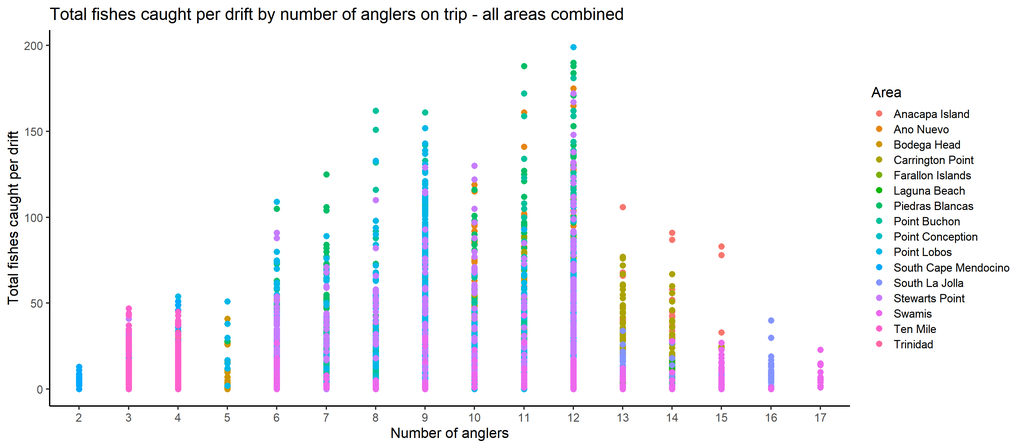

```r
#Raw Scatter Plots - each point is a drift

#Plot CPUE per drift by number of anglers for each sampling area
ggplot(cpue.total, aes(x = Total.Anglers, y = Total.Fishes.Caught, color=Area))+
  geom_point(size = 3, shape = 16) +
  ylab('Total fishes caught per drift')+
  xlab('Number of anglers')+
  ggtitle('Total fishes caught per drift by number of anglers on trip - all areas combined')
```

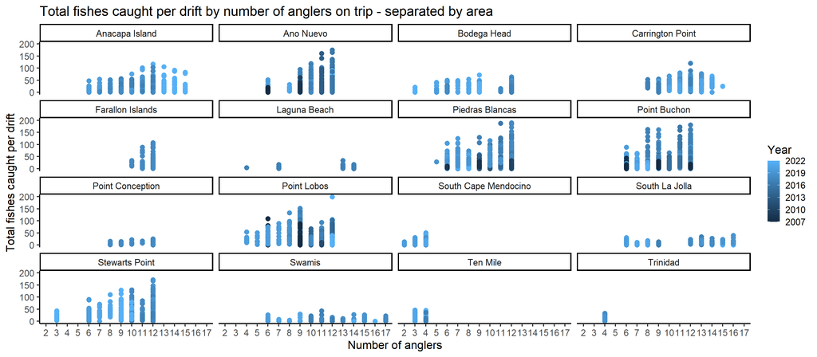

```r
#Plot CPUE per drift by number of anglers for each sampling area
ggplot(cpue.total, aes(x = Total.Anglers, y = Total.Fishes.Caught, color=Year))+
  geom_point(size = 3, shape = 16)+
  ylab('Total fishes caught per drift')+
  xlab('Number of anglers')+
  facet_wrap(~Area)+
  ggtitle('Total fishes caught per drift by number of anglers on trip - separated by area')
```

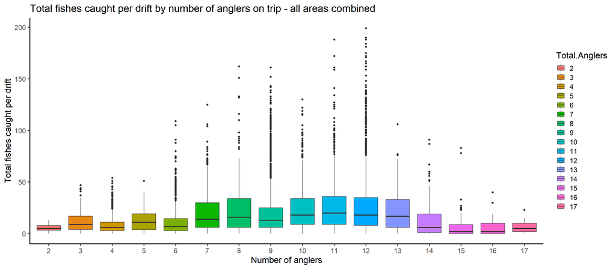

```r
#Box Plots

# Create boxplot using all drift-specific CPUE data
ggplot(cpue.total, aes(x = Total.Anglers, y = Total.Fishes.Caught, fill = Total.Anglers)) +
  geom_boxplot() +
  ylab('Total fishes caught per drift') +
  xlab('Number of anglers')+
  ggtitle('Total fishes caught per drift by number of anglers on trip - all areas combined')
```

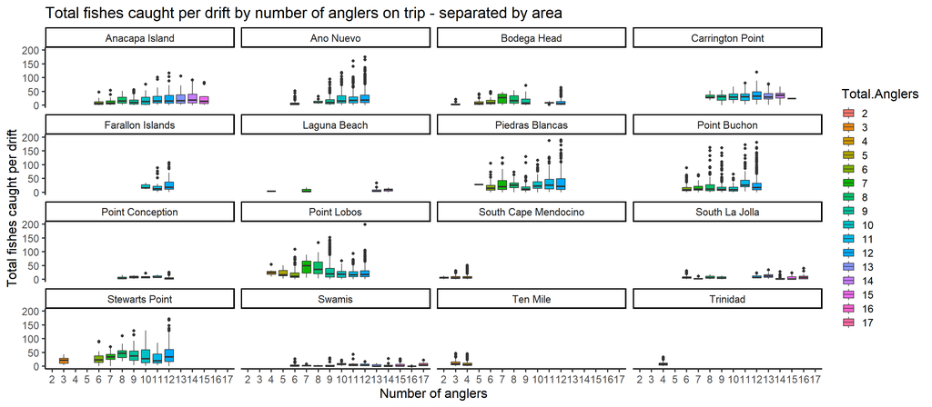

```r
# Create boxplot using all drift-specific CPUE data facet wrapping area
ggplot(cpue.total, aes(x = Total.Anglers, y = Total.Fishes.Caught, fill = Total.Anglers)) +
  geom_boxplot() +
  ylab('Total fishes caught per drift') +
  xlab('Number of anglers') +
  facet_wrap(~ Area)+
  ggtitle('Total fishes caught per drift by number of anglers on trip - separated by area')
```

Total fish CPUE per drift by number of anglers on a trip: (1) Scatter plot - all areas data (2) Scatter plot - separated by area (3) Box plot - all areas data (4) Box plot - separated by area

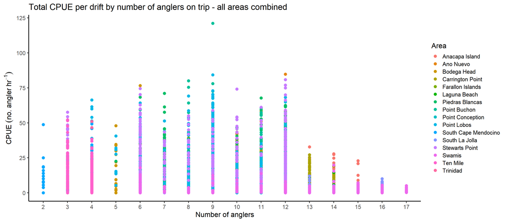

```r
#Raw Scatter Plots - each point is a drift

#Plot CPUE per drift by number of anglers for each sampling area
ggplot(cpue.total, aes(x = Total.Anglers, y = cpue, color=Area))+
  geom_point(size = 3, shape = 16) +
  ylab('CPUE')+
  labs(y=expression(CPUE~(no.~angler~hr^{-1})))+
  xlab('Number of anglers')+
  ggtitle('Total CPUE per drift by number of anglers on trip - all areas combined')
```

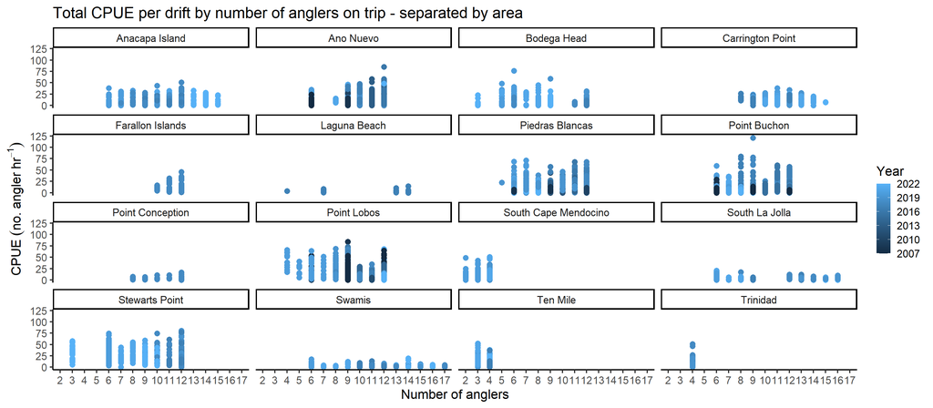

```r
#Plot CPUE per drift by number of anglers for each sampling area
ggplot(cpue.total, aes(x = Total.Anglers, y = cpue, color=Year))+
  geom_point(size = 3, shape = 16)+
  ylab('CPUE')+
  labs(y=expression(CPUE~(no.~angler~hr^{-1})))+
  xlab('Number of anglers')+
  facet_wrap(~Area)+
  ggtitle('Total CPUE per drift by number of anglers on trip - separated by area')
```

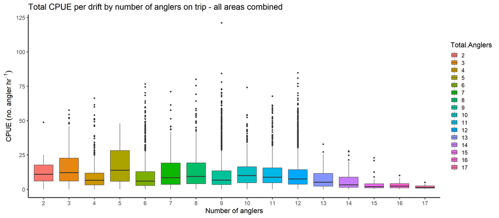

```r
#Box Plots

#Make angler totals a factor and not numeric
cpue.total$Total.Anglers <- as.factor(cpue.total$Total.Anglers)

# Create boxplot using all drift-specific CPUE data
ggplot(cpue.total, aes(x = Total.Anglers, y = cpue, fill = Total.Anglers)) +
  geom_boxplot() +
  ylab('CPUE') +
  labs(y = expression(CPUE~(no.~angler~hr^{-1}))) +
  xlab('Number of anglers')+
  ggtitle('Total CPUE per drift by number of anglers on trip - all areas combined')
```

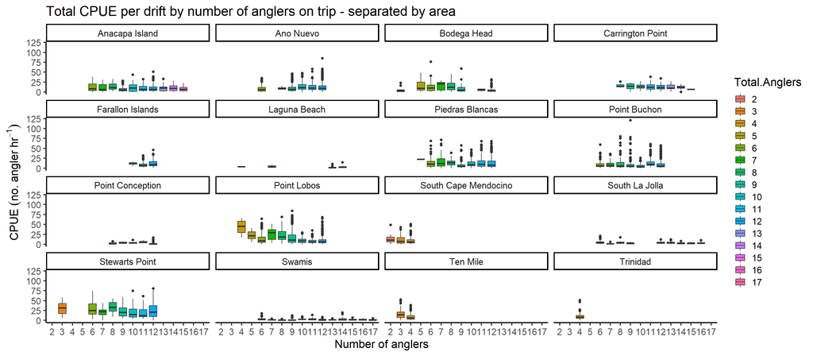

```r
# Create boxplot using all drift-specific CPUE data facet wrapping area
ggplot(cpue.total, aes(x = Total.Anglers, y = cpue, fill = Total.Anglers)) +
  geom_boxplot() +
  ylab('CPUE') +
  labs(y = expression(CPUE~(no.~angler~hr^{-1}))) +
  xlab('Number of anglers') +
  facet_wrap(~ Area)+
  ggtitle('Total CPUE per drift by number of anglers on trip - separated by area')
```

[output not shown]